# README

These are analysis operations and data for the study titled “Valenced Priming with Acquired Affective Concepts in Music: Automatic Reactions to Common Tonal Chords” by Imre Lahdelma and [Tuomas Eerola](https://tuomaseerola.github.io/) in the journal of *Music Perception*. Read this document at the [documentation site](https://tuomaseerola.github.io/cultural_priming/).

# Sample size

Here is the link to the scripts and functions for [planning](https://tuomaseerola.github.io/cultural_priming/planning.html) the sample size for one sub-experiment.

# Data analysis

Four sub-experiments, all collected separately using psytoolkit. Original data in zipped folder `raw_data.zip` and requires `compile_data.R` script. For convenience we rely on the exported CSV files per experiment.

## Load data

```r
rm(list = ls())
library(ggplot2)
library(see)
library(dplyr)
library(ggdist)
library(tidybayes)
options(dplyr.summarise.inform = FALSE)

#### 2. Compile or load data ------------------------------------------
#source('compile_data.R')          # simply reading in the raw data and aggregating the background
source('load_data.R')             # reading in the data that has been filtered (exgaussian, practice trials)
```

```
## [1] "AUG: N=102"
## [1] "DIM: N=99"
## [1] "MIN: N=100"
## [1] "SUS: N=101"
```

## Describe participants

```r
source('describe_participants.R')
d1 <- describe_participants(MIN)
```

```
## [1] "-----Age-------"
## [1] "Mean Age: 25.3"
## [1] "SD Age: 3.3"
## [1] "-----Musical Expertise (%)-------"
##
##     Musician Non-musician
##            4           96
## [1] "-----Gender (%)-------"
##
##  1  2  3  4  5
## 49 46  2  1  2
```

```r
d2 <- describe_participants(AUG)
```

```
## [1] "-----Age-------"
## [1] "Mean Age: 24.6"
## [1] "SD Age: 3.2"
## [1] "-----Musical Expertise (%)-------"
##
##     Musician Non-musician
##            9           91
## [1] "-----Gender (%)-------"
##
##  1  2  3  4  5  6
## 48 47  1  1  1  2
```

```r
d3 <- describe_participants(DIM)
```

```
## [1] "-----Age-------"
## [1] "Mean Age: 25.3"
## [1] "SD Age: 3.3"
## [1] "-----Musical Expertise (%)-------"
##
##     Musician Non-musician
##            3           97
## [1] "-----Gender (%)-------"
##
##  1  2  3
## 42 57  1
```

```r
d4 <- describe_participants(SUS)
```

```
## [1] "-----Age-------"
## [1] "Mean Age: 25.7"
## [1] "SD Age: 2.7"
## [1] "-----Musical Expertise (%)-------"
##
##     Musician Non-musician
##            6           94
## [1] "-----Gender (%)-------"
##
##  1  2  3  5
## 50 49  1  1
```

```r
source('background_across_substudies.R') # Compare backgrounds across the sub-experiments
```

```
##
## AUG DIM MIN SUS
## 102  99 100 101
##              Df Sum Sq Mean Sq F value Pr(>F)
## study         3     57  19.140   1.952  0.121
## Residuals   398   3902   9.805
##
##  Pearson's Chi-squared test with simulated p-value (based on 2000
##  replicates)
##
## data:  df$gender and df$study
## X-squared = 12.539, df = NA, p-value = 0.6787
##
##
##  Pearson's Chi-squared test with simulated p-value (based on 2000
##  replicates)
##
## data:  df$study and df$MusExpertise
## X-squared = 3.8175, df = NA, p-value = 0.2809
##
## [1] "across all sub-experiments"
## [1] "--------------------------"
## [1] "Age M: 25.22"
## [1] "Age SD: 3.14"
## [1] "Gender distr:"
##
##           1           2           3           4           5           6
## 0.472636816 0.495024876 0.012437811 0.004975124 0.009950249 0.004975124
## [1] "MusExpertise distr:"
##
##     Musician Non-musician
##   0.05472637   0.94527363
```

# Describe and Visualise data

First show the means across conditions (table).

```r
source('table_of_means.R')             # create table of means
```

[output not shown]

# Bayesian Analysis

```r
source('calculate_bayes.R')   # function to calculate

# One sub-experiment takes about 20 mins to analyse, save results
b1 <- calculate_bayes(SUS)
save(b1,file = 'data/SUS_bayesR1.RData')
b1 <- calculate_bayes(MIN)
save(b1,file = 'data/MIN_bayesR1.RData')
b1 <- calculate_bayes(AUG)
save(b1,file = 'data/AUG_bayesR1.RData')
b1 <- calculate_bayes(DIM) # 18 min
save(b1,file = 'data/DIM_bayesR1.RData')
```

## Describe models

Check the model performance and the group-level effects (disabled for now as the reporting is long).

```r
load('data/MIN_bayesR1.RData')
summary(b1)
brms::ranef(b1)

load('data/AUG_bayesR1.RData')
summary(b1)
brms::ranef(b1)

load('data/DIM_bayesR1.RData')
summary(b1)
brms::ranef(b1)

load('data/SUS_bayesR1.RData')
summary(b1)
brms::ranef(b1)
```

## Report Bayesian evidence

Test directional hypothesis about congruence.

```r
library(brms)

load('data/MIN_bayesR1.RData')
hyp_MIN <- brms::hypothesis(b1,"CongruenceN > 0",seed=1234,scope="standard",robust=TRUE)
load('data/AUG_bayesR1.RData')
hyp_AUG <- brms::hypothesis(b1,"CongruenceN > 0",seed=1234,scope="standard",robust=TRUE)
load('data/DIM_bayesR1.RData')
hyp_DIM <- brms::hypothesis(b1,"CongruenceN > 0",seed=1234,scope="standard",robust=TRUE)
load('data/SUS_bayesR1.RData')
hyp_SUS <- brms::hypothesis(b1,"CongruenceN > 0",seed=1234,scope="standard",robust=TRUE)
```

## Bayesian analysis summary table

Draw analysis results together as a table.

```r
table2 <- rbind(hyp_MIN$hypothesis,hyp_AUG$hypothesis,hyp_DIM$hypothesis, hyp_SUS$hypothesis)
rownames(table2)<-c("Major-Minor","Major-Augmentd","Major-Diminished","Major-Suspended 4")
table2$Hypothesis<-'Congruence > 0'
knitr::kable(table2,digits = 4,caption='Summary of the analyses of each sub-experiment.')
```

Summary of the analyses of each sub-experiment.

|  | Hypothesis | Estimate | Est.Error | CI.Lower | CI.Upper | Evid.Ratio | Post.Prob | Star |
| --- | --- | --- | --- | --- | --- | --- | --- | --- |
| Major-Minor | Congruence > 0 | 0.0035 | 0.0020 | 0.0001 | 0.0069 | 20.6802 | 0.9539 | * |
| Major-Augmentd | Congruence > 0 | 0.0047 | 0.0020 | 0.0013 | 0.0080 | 79.8081 | 0.9876 | * |
| Major-Diminished | Congruence > 0 | 0.0070 | 0.0021 | 0.0036 | 0.0105 | 3999.0000 | 0.9998 | * |
| Major-Suspended 4 | Congruence > 0 | 0.0026 | 0.0019 | -0.0005 | 0.0057 | 11.1396 | 0.9176 |  |

## Mean marginal effects in milliseconds

```r
library(emmeans)
load('data/MIN_bayesR1.RData')

draws <- b1 %>%
  emmeans(~ CongruenceN,epred = TRUE) %>%
  contrast(method = "revpairwise") %>%
  gather_emmeans_draws()

draws %>% median_hdi()
```

```
## # A tibble: 1 × 7
##   contrast                       .value .lower .upper .width .point .interval
##   <chr>                           <dbl>  <dbl>  <dbl>  <dbl> <chr>  <chr>
## 1 CongruenceN1 - (CongruenceN-1)   2.99 -0.431   6.43   0.95 median hdi
```

```r
g1 <- ggplot(draws, aes(x = .value)) +
  stat_halfeye(fill = 'grey70') +
  labs(x = "Marginal effect of Congruence (ms)", y = "Density",title = 'Major-Minor') +
  see::theme_modern() +
  theme(legend.position = "bottom")+
  scale_x_continuous(limits = c(-3,12),breaks = seq(-3,12,by=3))+
  theme(text = element_text(size = 16,  family = "Palatino")) +
  theme(plot.title = element_text(hjust = 0.5))

load('data/AUG_bayesR1.RData')

draws <- b1 %>%
  emmeans(~ CongruenceN,epred = TRUE) %>%
  contrast(method = "revpairwise") %>%
  gather_emmeans_draws()

draws %>% median_hdi()
```

```
## # A tibble: 1 × 7
##   contrast                       .value .lower .upper .width .point .interval
##   <chr>                           <dbl>  <dbl>  <dbl>  <dbl> <chr>  <chr>
## 1 CongruenceN1 - (CongruenceN-1)   4.39  0.501   8.07   0.95 median hdi
```

```r
g2 <- ggplot(draws, aes(x = .value)) +
  stat_halfeye(fill = 'grey70') +
  labs(x = "Marginal effect of Congruence (ms)", y = "Density",title = 'Major-Augmented') +
  see::theme_modern() +
  theme(legend.position = "bottom")+
  scale_x_continuous(limits = c(-3,12),breaks = seq(-3,12,by=3))+
  theme(text = element_text(size = 16,  family = "Palatino")) +
  theme(plot.title = element_text(hjust = 0.5))

load('data/DIM_bayesR1.RData')

draws <- b1 %>%
  emmeans(~ CongruenceN,epred = TRUE) %>%
  contrast(method = "revpairwise") %>%
  gather_emmeans_draws()

draws %>% median_hdi()
```

```
## # A tibble: 1 × 7
##   contrast                       .value .lower .upper .width .point .interval
##   <chr>                           <dbl>  <dbl>  <dbl>  <dbl> <chr>  <chr>
## 1 CongruenceN1 - (CongruenceN-1)   6.29   2.79   9.89   0.95 median hdi
```

```r
g3 <- ggplot(draws, aes(x = .value)) +
  stat_halfeye(fill = 'grey70') +
  labs(x = "Marginal effect of Congruence (ms)", y = "Density",title = 'Major-Diminished') +
  see::theme_modern() +
  theme(legend.position = "bottom")+
  scale_x_continuous(limits = c(-3,12),breaks = seq(-3,12,by=3))+
  theme(text = element_text(size = 16,  family = "Palatino")) +
  theme(plot.title = element_text(hjust = 0.5))

load('data/SUS_bayesR1.RData')

draws <- b1 %>%
  emmeans(~ CongruenceN,epred = TRUE) %>%
  contrast(method = "revpairwise") %>%
  gather_emmeans_draws()

draws %>% median_hdi()
```

```
## # A tibble: 1 × 7
##   contrast                       .value .lower .upper .width .point .interval
##   <chr>                           <dbl>  <dbl>  <dbl>  <dbl> <chr>  <chr>
## 1 CongruenceN1 - (CongruenceN-1)   2.51  -1.12   6.04   0.95 median hdi
```

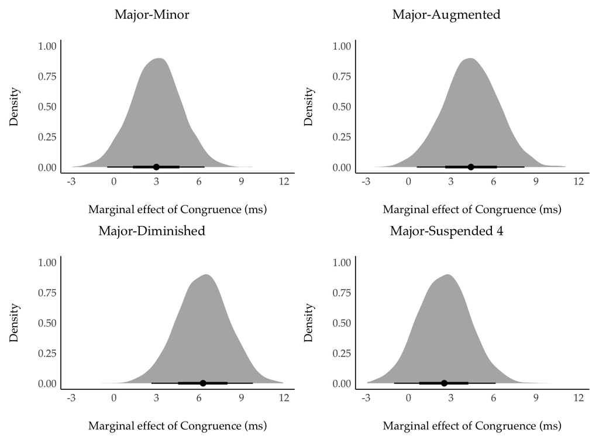

```r
g4 <- ggplot(draws, aes(x = .value)) +
  stat_halfeye(fill = 'grey70') +
  labs(x = "Marginal effect of Congruence (ms)", y = "Density",title = 'Major-Suspended 4') +
  see::theme_modern() +
  theme(legend.position = "bottom")+
  scale_x_continuous(limits = c(-3,12),breaks = seq(-3,12,by=3))+
  theme(text = element_text(size = 16,  family = "Palatino")) +
  theme(plot.title = element_text(hjust = 0.5))


G3 <- see::plots(g1, g2, g3, g4, n_columns = 2, tags = FALSE,guides = "collect")
G3
```

### Save Figure 1

```r
ggsave(filename = 'marginal_effects.png',plot = G3, device = 'png',dpi = 300,width = 9.5,height = 7)
```

## Plot posterior plots

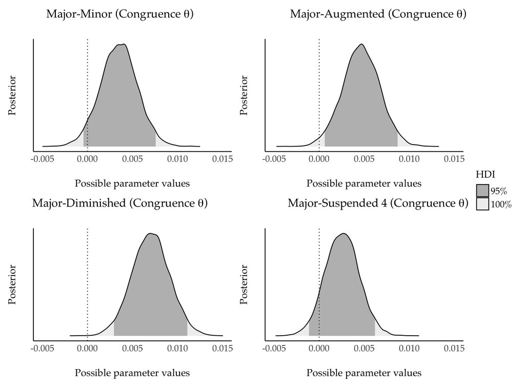

```r
library(extrafont)
library(latex2exp)

posterior_MIN <- hyp_MIN$samples
result_MIN <- bayestestR::hdi(posterior_MIN, ci = c(0.95))
p1 <- plot(result_MIN)+
  scale_fill_brewer(type = 'seq',palette = 'Greys',direction = -1)+
  see::theme_modern()+
  scale_x_continuous(limits = c(-0.005,0.015))+
  labs(title = TeX(r"(Major-Minor (Congruence $\theta$))"))+
   theme(text=element_text(size=16,  family="Palatino"))+
   theme(plot.title = element_text(hjust = 0.5))

posterior_AUG <- hyp_AUG$samples
result_AUG <- bayestestR::hdi(posterior_AUG, ci = c(0.95))
p2 <- plot(result_AUG)+
  scale_fill_brewer(type = 'seq',palette = 'Greys',direction = -1)+
  see::theme_modern()+
  scale_x_continuous(limits = c(-0.005,0.015))+
  labs(title = TeX(r"(Major-Augmented (Congruence $\theta$))"))+
   theme(text=element_text(size=16,  family="Palatino"))+
   theme(plot.title = element_text(hjust = 0.5))

posterior_DIM <- hyp_DIM$samples
result_DIM <- bayestestR::hdi(posterior_DIM, ci = c(0.95))
p3 <- plot(result_DIM)+
  scale_fill_brewer(type = 'seq',palette = 'Greys',direction = -1)+
  see::theme_modern()+
  scale_x_continuous(limits = c(-0.005,0.015))+
  labs(title = TeX(r"(Major-Diminished (Congruence $\theta$))"))+
   theme(text=element_text(size=16,  family="Palatino"))+
   theme(plot.title = element_text(hjust = 0.5))

posterior_SUS <- hyp_SUS$samples
result_SUS <- bayestestR::hdi(posterior_SUS, ci = c(0.95))
p4 <- plot(result_SUS)+
  scale_fill_brewer(type = 'seq',palette = 'Greys',direction = -1)+
  see::theme_modern()+
  scale_x_continuous(limits = c(-0.005,0.015))+
  labs(title = TeX(r"(Major-Suspended 4 (Congruence $\theta$))"))+
   theme(text=element_text(size=16,  family="Palatino"))+
   theme(plot.title = element_text(hjust = 0.5))

G<-see::plots(p1, p2, p3, p4, n_columns = 2, tags = FALSE,guides = "collect")
print(G)
```

### Save Figure 2

```r
ggsave(filename = 'thetas.png',plot = G, device = 'png',dpi = 300,width = 9.5,height = 7)
```

# Compare the evidence between the sub-experiments

Does *Major–Diminished* chord pair provide significantly stronger evidence than *Major–Augmented* pair using the posterior distributions? How large is the difference?

## Mean difference between the sub-experiments

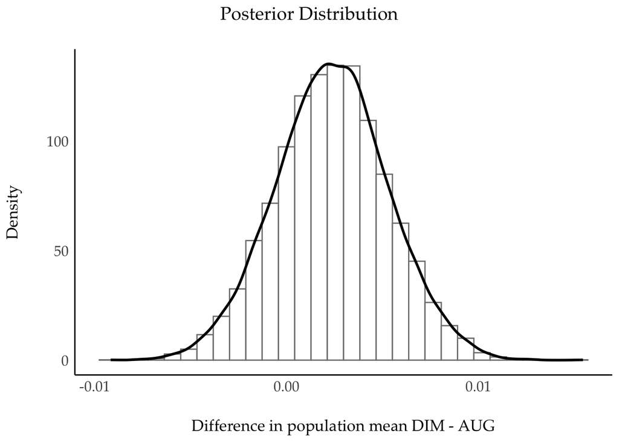

```r
library(bayestestR)
posteriors <-
  data.frame(DIM = posterior_DIM$H1, AUG = posterior_AUG$H1) # join the posteriors of interest

# calculate the mean difference

posteriors = posteriors %>%
  mutate(mu_diff = DIM - AUG) # calculate difference

ggplot(posteriors, aes(mu_diff)) +
  geom_histogram(aes(y = ..density..),
                 color = "grey50",
                 fill = "white") +
  geom_density(linewidth = 1, color = "black") +
  xlab("Difference in population mean DIM - AUG") +
  labs(x = "Difference in population mean DIM - AUG", y='Density', title = "Posterior Distribution") +
  see::theme_modern() +
  theme(text = element_text(size = 16,  family = "Palatino")) +
  theme(plot.title = element_text(hjust = 0.5))
```

```r
quantile(posteriors$mu_diff, c(0.01, 0.10, 0.25, 0.50, 0.75, 0.90, 0.99))
```

```
##            1%           10%           25%           50%           75%
## -0.0044358092 -0.0014222758  0.0004144141  0.0023701172  0.0043014859
##           90%           99%
##  0.0061098076  0.0092661480
```

```r
sum(posteriors$mu_diff > 0) / length(posteriors$mu_diff) # 0.7937
```

```
## [1] 0.79375
```

```r
d <- bayestestR::ci(posteriors$mu_diff,ci = 0.95)
d$CI_low
```

```
## [1] -0.003413847
```

```r
d$CI_high
```

```
## [1] 0.008172973
```

There is a posterior probability of about 79 percent that the congruence for DIM is greater than the mean congruence for AUG.

# Frequentist analysis

For a comparison (and for a comfort), let’s run linear mixed model (LMM) with the same parameters (random factors) as defined in the Bayesian model.

```r
lmer_analysis <- function(data = NULL) {
  # lmer_analysis.R

  df <- data

  library(lme4)
  library(lmerTest)
  library(emmeans)
  library(nlme)
  options(contrasts = c("contr.sum", "contr.poly"))

  m0_lmm <-
    lmer(log(RT) ~ Congruence + (1 + Congruence |
                                   Id) + (1 | RandTransp) + (1 | Word),
         data = df)
  return <- summary(m0_lmm)
}
```

Run the model for each sub-experiment and summarise results.

```r
lmm1 <- lmer_analysis(data = MIN) # 0.0854
lmm2 <- lmer_analysis(data = AUG) # 0.0273
lmm3 <- lmer_analysis(data = DIM) # 0.0007
lmm4 <- lmer_analysis(data = SUS) # 0.141

s1 <- summary(lmm1)
s2 <- summary(lmm2)
s3 <- summary(lmm3)
s4 <- summary(lmm4)

S <-
  rbind(s1$coefficients[2, ],
        s2$coefficients[2, ],
        s3$coefficients[2, ],
        s4$coefficients[2, ])
rownames(S) <-
  c('Major-Minor',
    'Major-Augmented',
    'Major-Diminished',
    'Major-Suspended 4')
knitr::kable(S, digits = 4)
```

|  | Estimate | Std. Error | df | t value | Pr(>\|t\|) |
| --- | --- | --- | --- | --- | --- |
| Major-Minor | -0.0027 | 0.0016 | 4728.7636 | -1.7203 | 0.0854 |
| Major-Augmented | -0.0038 | 0.0017 | 86.8123 | -2.2452 | 0.0273 |
| Major-Diminished | -0.0056 | 0.0017 | 1926.6992 | -3.3853 | 0.0007 |
| Major-Suspended 4 | -0.0024 | 0.0017 | 1844.7164 | -1.4736 | 0.1408 |